# Operational Efficacy and Effectiveness of a Maternal and Child Health (MCH) Conditional Cash Transfer Pilot Programme in Nigeria

**Authors**  
Chioma Oduenyi<sup>1,</sup> <sup>2,</sup> <sup>3</sup>, Victor Ordu<sup>1,</sup> <sup>4</sup> and Ugo Okoli<sup>2,</sup> <sup>3</sup>

**Author Affiliations**  
<sup>1</sup>Global Health and Medical Consultants Limited, Nigeria. <sup>2</sup>SURE-P MCH Project Implementation Unit, National Primary Health Care Development Agency, Abuja, Nigeria. <sup>3</sup>Jhpiego, Nigeria-affiliate of Johns Hopkins University, <sup>4</sup>National Environmental Standards and Regulations Enforcement Agency, Nigeria.

## Abstract

**Background**  
This paper provides insights into the design and implementation of the Subsidy Reinvestment and Empowerment Programme on Maternal and Child Health (SURE-P MCH) Conditional Cash Transfer (CCT) pilot programme in Nigeria. Operational processes of the CCT programme from design to enrollment and pay-out were assessed independently to inform future CCT designs and implementation.

**Results**  
The SWOT analysis indicated that the CCT programme had a robust design with huge potentials of operational effectiveness, had it been implemented as designed. However, the programme was inundated with several implementation challenges. Though 65% of beneficiaries perceived CCT pay-out events as orderly and well-organized (p < 0.001), yet, marred with inconsistencies and irregularities resulting in large crowds and increased waiting time for beneficiaries. Only 40% of beneficiaries received the complete N5,000 (USD30) cash incentive, 28% received only N1,000 (USD6) while others received either N2000 (USD12), N3000 (USD18) or N4000 (USD24).

**Conclusion**  
The CCT pilot programme had a robust design following a proof of concept phase that preceded the roll-out of the pilot programme. However, its implementation was marred with several challenges ranging from untimely release of funds, limited monitoring and evaluation and other operational challenges. Future CCT programmes should understudy the SWOT analysis presented in this paper to improve design and implementation of CCT programmes in Nigeria and other settings.

**Key Words:** SURE-P MCH, Conditional Cash Transfers, operational processes, SWOT analysis, efficacy and effectiveness

## Background

Nigeria’s high maternal mortality of 576 per 100,000 live births and infant mortality of 70 per 1000 live births [1, 2] remain worrisome and reflects inequality in maternal and infant mortality due to poverty. Hence one strategy to fight health inequality due to poverty is conditional cash transfer (CCTs) [3]. In a bid to reverse the worrying trend, the Federal Government of Nigeria (FGN) initiated the SURE-P maternal and child health programme (SURE-P MCH) which combined supply and demand-side interventions. Initially launched in 500 primary health care (PHCs) facilities across Nigeria’s 36 states and the Federal Capital Territory (FCT) and later scaled to 1000 facilities [4]. As part of the demand –side intervention, a conditional cash transfer (CCT) component was introduced as a pilot programme to increase demand for basic maternal, newborn and child health (MNCH) services rather than poverty reduction as emphasized by earlier CCT schemes [5]. The CCT scheme was implemented in Nigeria’s Federal Capital Territory (FCT), Abuja and 8 states of the federation; Anambra, Bauchi, Bayelsa, Ebonyi, Kaduna, Niger, Ogun, and Zamfara – for a geographic spread. The CCT scheme with an annual budget of over N100,000,000 (USD 602,410), was designed to incentivize enrolled beneficiaries who fulfil a set of four co-responsibilities along the continuum of care for MNCH services in designated PHCs to reduce the impact of economic barriers to access to health services e.g. transportation to the PHC and out-of-pocket expenses[6]. Pro-rated cash support of up to N5,000 (approximately USD 30) was provided to qualified pregnant women who go through the continuum of care, from antenatal through post-natal care. The value of N5,000 or USD30 as at year 2012 was determined by average estimates of costs incurred by pregnant women to access and utilize the facility, drawn from findings of the proof-of-concept phase [5].

Most CCTs are targeted at disadvantaged or vulnerable people as investments in human capital and in addition to providing immediate poverty relief [6]. The last two decades have seen an upsurge in the use of conditional cash transfers (CCTs) as innovative approaches to deliver social goods to vulnerable populations around the world [7–9]. Since, Mexico implemented *Oportunidades* and Brazil’s *Bolsa Familia Programme* (BFP), several countries have implemented CCTs from Latin Americas to Asia such as the Janani Suraksha Yojana (JSY) CCT programme in India [10] and Indonesia’s large-scale CCTs scheme known as Program Keluarga Harapan (PKH) [3, 11]. Sub-saharan Africa such as Kenya have also implemented CCTs and most recently in developed countries such as England and “Opportunity New York City” (ONYC) in the United States [12–15]. As a lead social protection initiative to address poverty and vulnerability, CCT is not totally new to Nigeria. Nigeria has had its own share of CCT schemes at different scales and with varied focus since the 2000s and while some were state-sponsored (i.e. subnational), others were federal government-sponsored. Prominent among them was Nigeria’s “In Care of the People” (COPE) launched in 2007 across 12 states, targeted at reducing socio-economic vulnerabilities and breaking the cycle of intergenerational poverty [16]. The effectiveness of COPE became questionable as monitoring and evaluation (M&E) mechanisms were conspicuously lacking and many challenges were found with programme delivery and infrastructure [16]. Other programmes included CCTs to support girl-child education in three Northern states, Kano, Bauchi and Katsina assisted by the World Bank, DFID and UNICEF; Jigawa State, sponsored a disability allowance programme, while Bayelsa state sponsored a child savings scheme. Cross River State also sponsored a CCT programme for poor households and Ekiti State targeted the elderly above 65 years who did not earn pensions (though unconditionally) [16].

## Description of the SURE-P MCH CCT Pilot Programme

Through the SURE-P MCH supply side interventions, trained midwives and Community Health Extension Workers (CHEWs) were deployed to designated facilities across Nigeria’s 36 states and the FCT, and the skill sets of existing cadres of health staff across health facilities were strengthened [24]. MNCH medicines, consumables, equipment were supplied and infrastructural developments such as the renovation of primary health centres and provision of bore holes for potable water were put in place. On the demand creation interventions, SURE-P MCH utilized the conditional cash transfer (CCT) programme as a key MNCH services demand booster, to complement the huge supply-side interventions [25]. Nevertheless, the SURE-P MCH CCT programme was introduced to assess whether the added cash incentive would have a significant impact on the utilization of ante-natal care services and facility-based delivery among pregnant women in SURE-P MCH target communities. Following a six-month proof of concept phase where the concept was fine-tuned in Kuje PHC and Karu PHC, both in FCT –Abuja, the SURE-MCH CCT pilot programme was officially launched on May 13, 2013 at Deidei Comprehensive Health Centre Bwari, Bwari Area Council Abuja-FCT. A cluster model was used to select four (4) Primary Health Care (PHC) facilities per state with the exception of FCT-ABUJA which had five (5) PHC facilities making a total of 37 participating primary health care (PHC) facilities in 10 CCT clusters [27, 28].

## Design of the SURE-P MCH CCT Programme

### Programme Beneficiaries

The primary beneficiaries of the CCT Programme were pregnant women who enrolled at designated SURE-P MCH CCT PHCs. However, secondary beneficiaries included their newborns, wider household (including existing children) as mothers’ contact with health services increased over the period and their husbands who were relieved of some out-of-pocket expenses.

### Eligibility

All pregnant women whose pregnancy status were confirmed and booked in each participating facility and who were yet to benefit from the CCT program met the eligibility criteria. The CCT Pilot programme incentivized beneficiaries with a total of N5000 (approximately USD30) cash support after fulfilling a set of four (4) co-responsibilities as detailed in Figure 1.

### Cash Transfers

The cash disbursement was designed to be done in two tranches, where each woman received the first disbursement of N1,000 after registration at a participating PHC. The second and final disbursement was up to N4,000, according to the co-responsibilities completed for ANC, delivery with skilled birth attendant, postnatal care, neonate immunization, and family planning advice.

### Referral to General Hospitals

In line with the design of the CCT programme, enrollees were entitled to free care at a secondary health facility (general hospital) in their cluster if referred for elective or emergency obstetric treatment. However, the desk review identified that beneficiaries who had complications and were referred to general hospitals faced a lot of hitches and no beneficiaries benefited from this service owing to programmatic challenges.

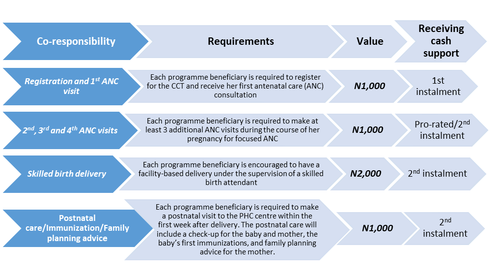

SURE-P MCH CCT Co-Responsibilities and Benefits

Figure 1: SURE-P MCH CCT Co-Responsibilities and Benefits

### Programme Administration and Operations

Prior to the CCT implementation, a two-week State Readiness Assessment (SRA) was conducted across all participating states to create awareness and sensitize various stakeholders at the state, local government area (LGA) and ward levels on the SURE-P MCH CCT pilot programme and implementation plans. In each state, one CCT Technical Officer, one Field Supervisor and two Field Officers were recruited and a State Steering Committee (SSC) comprising of the Honourable Commissioner State Ministry of Health, Ministry of Women Affairs, Ministry of Local Government and Chieftaincy Affairs including Traditional and Religious Leaders, State Director Primary Health Care, State Millennium Development Goals (MDGs) Focal Person, MSS Focal Person, and SURE-P State CCT Technical Officer was inaugurated to guide the implementation in each state and to ensure strong stakeholder collaboration.

Prior to CCT enrollment and registration of beneficiaries, service providers i.e. Midwives, CHEWs and Village Health Workers (VHWs) were trained on programme implementation while Ward Development Committee (WDC) members in all designated PHCs, who were either re-activated or newly established were given an orientation on the programme processes and what their responsibilities would be. CCT reporting tools including Beneficiary Registration Cards, CCT Facility Registers, CCT Personal Consultation Forms and CCT Referral Forms were developed and deployed to all participating health facilities prior to registration and enrollment of pregnant women.

### CCT pay–roll processe

Pay-rolls were usually generated from a spreadsheet containing list of eligible beneficiaries, their registration numbers and the amount of cash support qualified based on pre-conditions met. Prior to pay-out events, SSC, WDC and OICs of health facilities were duly informed about the dates. The pay-roll containing the payment schedule of beneficiaries was usually displayed at the notice board of the health facility to notify eligible beneficiaries about their qualification to receive the cash incentives. Additionally, the CCT technical staff would contact all qualified beneficiaries by telephone and inform them about the proposed pay-out day and also mobilize them for the event. CCT Pay-out information was also sent to the community through the VHW, who inform the women about the date and time for the cash disbursements. The pay-roll was used on pay-out days to invite beneficiaries for their cash disbursements. However, several challenges such as omission of the names of eligible participants from the pay-roll and irregularities in the pay-roll negatively affected the pay-roll processes.

### Pay-out events

The CCT pay-out event was the climax of the CCT programme because that was the day beneficiaries received their cash disbursements and was usually a one-day event but with possible spill-over into the next day. The pay-out event venues were usually organized with different stations in a linear manner to allow benefiting women move in a chronological manner for accreditation and validation before receiving their cash support. Thereafter, the CCT beneficiary receives their accrued cash support from bank cashiers who were present at the venues and working with the support of CCT operational staff. When a woman receives a total of N5000 (USD30) cash support having fulfilled all four co-responsibilities, the CCT registration card was retrieved from her and archived. However, following the deviation of the cash disbursements from two installments to single payment for several beneficiaries, the CCT pay-out events attracted high numbers of qualified women whose payments were due at the same time resulting in the over-crowding of pay-out events and resulting in long waiting times for beneficiaries.

## METHODS

### Study Design

The study was a combination of a desk review of SURE-P MCH CCT operational documents and a descriptive cross-sectional, retrospective survey of CCT primary beneficiaries using face-to-face interviewer administered questionnaires to elicit responses. The desk review understudied the SURE-P MCH Programme Implementation Manual (PIM), and several SURE-P MCH CCT monthly reports obtained from the project management unit (PIU) while a structured questionnaire of (16) questions was used for the face-to-face interviews with CCT primary beneficiaries. At the end of the desk review and interviews, a SWOT analysis was applied to the study findings to identify key strengths and weaknesses of the CCT scheme as well as opportunities and threats in order to identify key challenges and provide recommendations for future design and implementation of CCT Programmes in Nigeria and other settings.

### Study Population

Study population was drawn from 37 participating CCT pilot PHC facilities in FCT-Abuja and eight (8) participating states of Anambra, Bauchi, Bayelsa, Ebonyi, Kaduna, Niger, Ogun, and Zamfara (Figure 2). However, following security and accessibility challenges, assessors were unable to reach all four (4) facilities in some states like Bauchi, Kaduna, Niger, Ogun and Zamfara, hence respondents were drawn from only 29 PHC facilities out of the 37 participating facilities. Respondents were pregnant women or nursing mothers who enrolled in the CCT programme during the pilot period from April, 2013 to May 2015 and who received cash incentives for meeting any of the four co-responsibilities.

### Sampling

A list of all women who enrolled in the pilot programme with their telephone contacts served as the sampling frame from which a table of random numbers generated with the Mersenne-Twister system was used to recruit participants into the study and participants who could not be reached on phone were replaced from the sampling frame by simply repeating the table of random numbers. The sampling frame consisted of all 37,737 CCT pilot enrollees (Table 1).

| State | No. of Enrollees |
| --- | --- |
| ANAMBRA | 1425 |
| BAUCHI | 4120 |
| BAYELSA | 2571 |
| EBONYI | 2752 |
| FCT | 16390 |
| KADUNA | 2733 |
| NIGER | 2168 |
| OGUN | 1435 |
| ZAMFARA | 4143 |

Table 1: CCT Pilot Enrollees by State

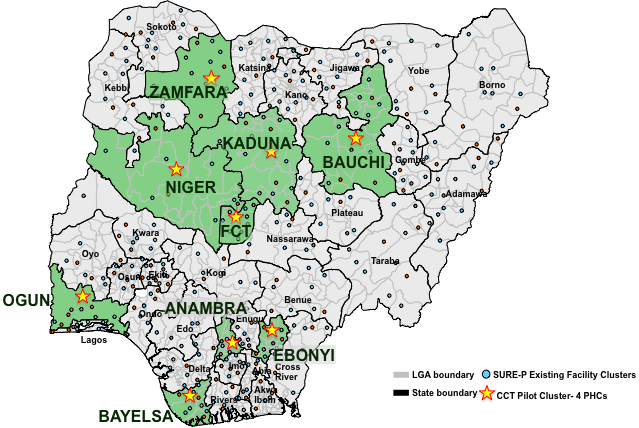

Map of CCT Pilot States depicting the sites surveyed

Figure 2: Map of CCT Pilot States depicting the sites surveyed

### Data collection process

Data were collected between June-July 2015 (when the CCT scheme had already ended) and started with the recruitment of Study Assessors who were trained in the interview process, administration of data collection instrument and techniques for conducting effective focus group discussions. Demographic data was collected on sex, age, religion, ethnic group, marital status, educational status, employment status, number of children and parity. Assessors combined English with local languages to elicit responses from participants where and when necessary.

### Data management and analysis

Each of the answered questionnaires was coded and entered into a spreadsheet. The data collected was subjected to descriptive (i.e. mean, median and mode) and inferential (i.e. Chi-square) statistical treatment. Bivariate analysis and test of statistical significance were carried out using R version 3.1.2.[26] Data from respondents were grouped into themes for analysis thus; CCT operations, CCTs pay- roll processes, CCTs pay-out events and perceived perception by beneficiaries. Finally, information obtained was summarized and presented in tables, charts and frequencies.

### Validity and reliability checks

The data collection instruments were put through phased validation which involved pre-testing and field testing. First, the tools were pre-tested and peer-reviewed by internal and external colleagues to ensure internal consistency and validity. Then, a field testing of the questionnaires and survey methodology was done in one of the non-participating CCT facilities in FCT-Abuja with all Assessors, who were part of the assessment training. Findings from the field-testing were incorporated and amended accordingly.

## FINDINGS FROM BENEFICIARY SURVEY

### Demographics

31.5% of beneficiaries were unemployed (i.e. housewives), 30.5% traders and 75% had a personal income equal to or less than N10,000 monthly.

### CCT Operations

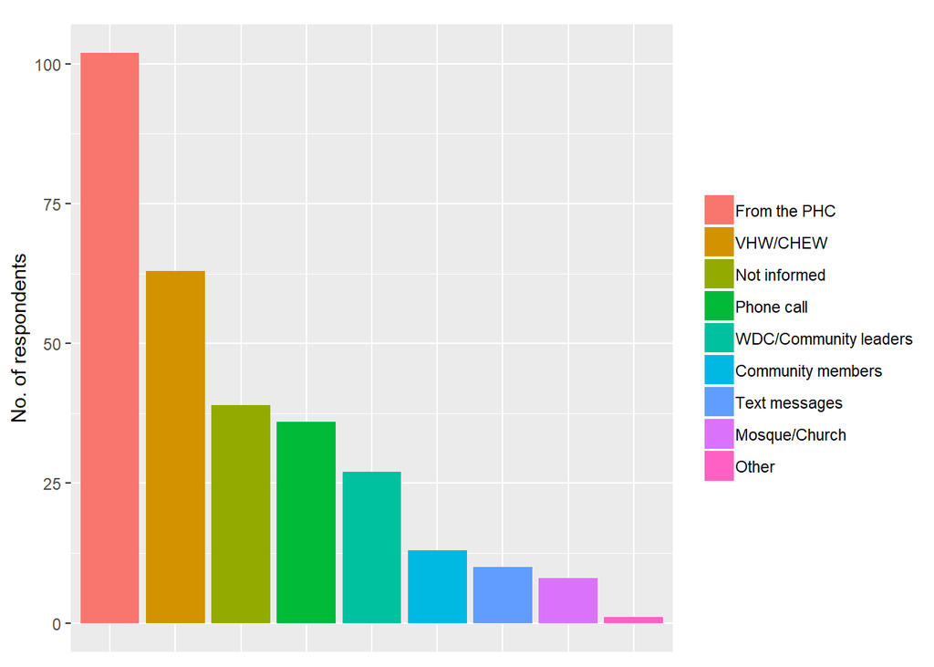

Where Beneficiaries first heard about CCT

Figure 3: Where Beneficiaries first heard about CCT

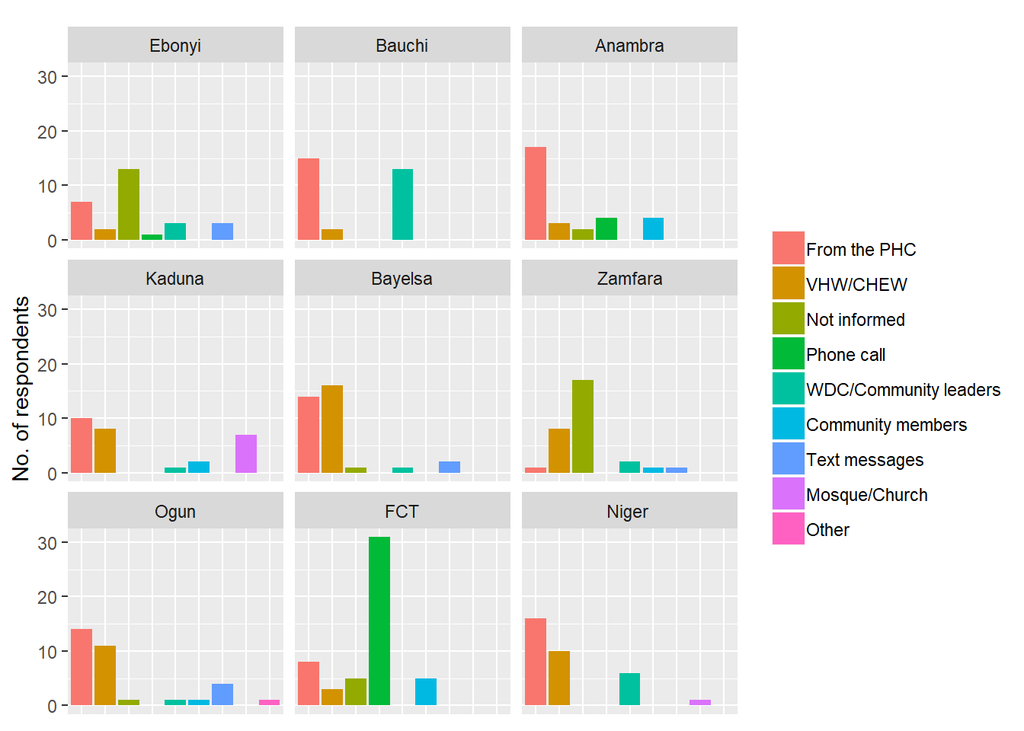

Where Beneficiaries first heard about CCT (by Pilot State)

Figure 4: Where Beneficiaries first heard about CCT (by Pilot State)

| Stage at Enrolment | No. | % |
| --- | --- | --- |
| First trimester | 122 | 40.00 |
| Second trimester | 163 | 53.44 |
| Third trimester | 19 | 6.23 |
| At delivery | 1 | 0.33 |

Table 2: Pregnancy Stage at CCT Enrolment

Most beneficiaries were enrolled in the pilot within the first 2 trimesters of their pregnancies (93%, Table 2), adequate information on their co-responsibilities was given to them at enrolment and they generally attested to the regularity of their CCT records.

### CCT Pay-roll and payout events

| Perception | Freq | % |
| --- | --- | --- |
| Easy | 287 | 92.28 |
| Not so easy | 20 | 6.43 |
| Difficult | 1 | 0.32 |
| Very difficult | 3 | 0.96 |

Table 3: Perception of CCT Process

| Source | No. | % |
| --- | --- | --- |
| From the PHC | 102 | 34.11 |
| VHW/CHEW | 63 | 21.07 |
| Not informed | 39 | 13.04 |
| Phone call | 36 | 12.04 |
| WDC/Community leaders | 27 | 9.03 |
| Community members | 13 | 4.35 |
| Text messages | 10 | 3.34 |
| Mosque/Church | 8 | 2.68 |
| Other | 1 | 0.33 |

Table 4: How Beneficiaries Heard About Pay-Out Events

| State | Yes | No | Don’t know |
| --- | --- | --- | --- |
| Ebonyi | 16 | 2 | 0 |
| Bauchi | 30 | 0 | 0 |
| Anambra | 28 | 0 | 0 |
| Kaduna | 25 | 3 | 0 |
| Bayelsa | 34 | 0 | 0 |
| Zamfara | 12 | 5 | 11 |
| Ogun | 31 | 1 | 0 |
| FCT | 47 | 0 | 0 |
| Niger | 12 | 20 | 0 |

Table 5: Were Pay-Outs According To Schedule?

Most of the women said that they were paid the complete N5,000 incentive (39.8%), followed by those who received only N1,000 (28.1%). Most of the respondents who received the incentive were paid in a single instalment.

There was a statistically significant variation ($\chi^2$ = 96.4, p < 0.001) amongst the CCT Pilot States of the amount received by the beneficiaries; the highest proportion of those that collected N5,000.00 were from FCT (30.4%) while 38.4% of those that collected only N1,000.00, were from Niger State. It should be noted that the CCT Pilot Programme started in the FCT several months before the other States.

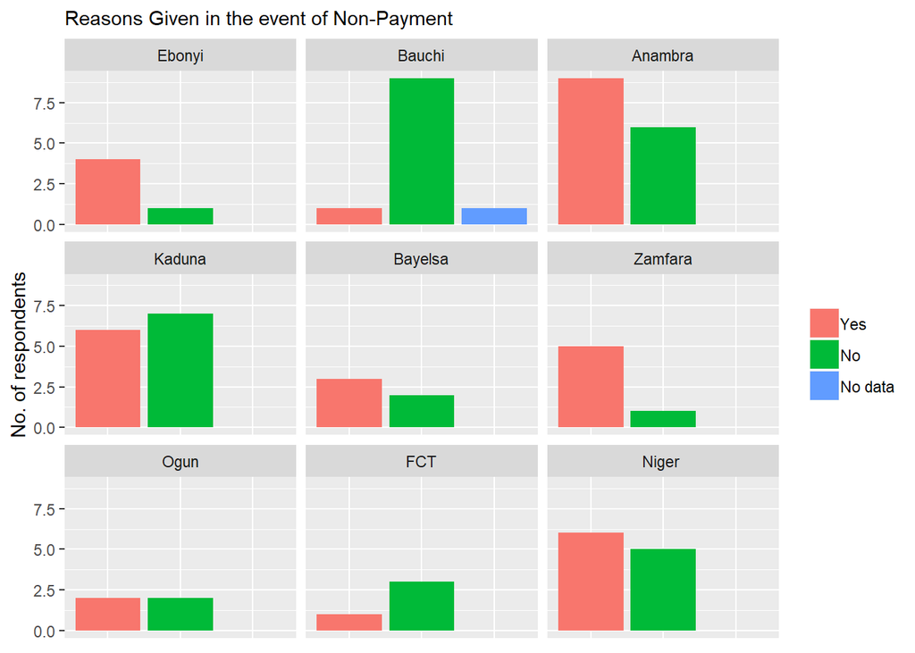

Beneficiaries Given Reasons for Non-Payment

Figure 5: Beneficiaries Given Reasons for Non-Payment

| State | Well organised | Fairly organised | Not organised |
| --- | --- | --- | --- |
| Ebonyi | 11 | 1 | 2 |
| Bauchi | 2 | 20 | 5 |
| Anambra | 24 | 1 | 0 |
| Kaduna | 22 | 5 | 1 |
| Bayelsa | 33 | 0 | 1 |
| Zamfara | 12 | 0 | 0 |
| Ogun | 30 | 2 | 0 |
| FCT | 23 | 17 | 7 |
| Niger | 8 | 25 | 1 |

Table 6: Description of Pay-Out Events in Pilot States

Table 7: Strength, Weaknesses, Opportunities, Threat (SWOT) Analysis

[output not shown]

[output not shown]

Table 8: KEY CHALLENGES

[output not shown]

## DISCUSSION

Furthermore, women qualified for cash disbursements reported that they were mostly informed about the pay-out events via the health facility (34.2%), VHW/CHEW (21.1%) and WDC (9.1%) and this is consistent with the earlier findings that local health system structures play a more prominent role in disseminating information on Pay-Out Events [30]. Significantly, the phone calls from SURE-P CCT Officers were also prominent sources of information, according to about 12.1% of the respondents and 95% of the respondents reported that the information they received was timely. Unfortunately, beneficiaries who were entitled to free care at the general hospital when referred from their PHC for elective or emergency obstetric treatment faced a lot of hitches as they expressed their frustrations in accessing that level of care.

The apparently smooth operational processes that characterized enrolment into the scheme up to pay-out was hampered by irregularities that inundated the pay-out events. These irregularities were reported to be as a result of irregular availability of funds from the federal government; thus the CCT programme deviated from its initial design of two installments disbursements to making single disbursements. Many beneficiaries that were eligible for payments had to receive their cash transfers in one installment and this obviously contributed to the overcrowding experienced at pay-out events. The desk review showed that the CCT disbursements was designed to be conducted in two tranches per woman, the first after registration and the second upon meeting the remaining co-responsibilities. However, the single payment thwarted the essence for the design decision which was to make pay-outs as prompt as possible, which is necessary for building beneficiaries’ trust and for the cash to serve its intended purpose of reducing healthcare costs for mothers [5]. The use of a cash and paper-based payment systems to track and pay clients, [31] heightened the need for adequate security for the cash and staff involved in the pay-out events and also raised the risk of corruption or fraud. This also indicate that implementing a CCT programme involves huge administrative and management costs as several staff are usually needed to successfully execute activities at the different levels of the process.

## CONCLUSION

The major strength of the SURE-P MCH CCT was its design to complement other supply-side interventions, as this helped to deepen health-seeking behavior, as the free services provided at the facility served as a motivating factor. Evidence shows that for a demand-side intervention such as CCT to be successful, concurrent supply-side inputs should be available [30]. Despite demonstrating a robust design of the CCT programme, its operational processes were marred with numerous challenges including: delay in cash disbursements to qualified beneficiaries owing to delayed replenishment from the federal government; omission of eligible participants names from the pay-roll; irregularities on the pay-roll; over-crowding of pay-out events leading to long waiting times and lack of access to referral facilities in case of emergencies or obstetric complications. Also, the CCT pay-outs lacked a clear monitoring framework that would have helped the programme to make necessary process amendments to improve outcome of the pay-out events. This conspicuous lack of (M&E) mechanisms is similar to COPE’s implementation which was also inundated with several service delivery challenges that undermined programme delivery and effectiveness [14]. Monitoring programme uptake and performance in each implementing cluster is essential to track and address programmatic challenges which may be the result of operational barriers [5].

The 93% enrollment recorded within first 2 trimesters indicates that the CCT programme encouraged women to register and attend antenatal visit (ANC) and Skilled Birth delivery hence, motivating positive behavior change by beneficiaries and their communities [3, 32]. This paper identified key challenges that marred the operational efficacy and effectiveness of the CCT programme but at the same time provided key recommendations to mitigate such challenges in the future. Future CCT programmes should understudy the SWOT analysis presented in this paper to guide future interventions in Nigeria and beyond.

Table 9: KEY RECOMMENDATIONS

[output not shown]

## LIMITATIONS OF STUDY

This study was limited by the paucity of literature on previous CCTs in Nigeria to support the desk review, though all literature available was considered. Also, the inability to assess more beneficiaries from all 37 facilities following security issues and inaccessibility of some terrain were limiting. However the 29 facilities and 314 beneficiaries assessed still gave a fair assessment of all participating states covered.

### Abbreviations

ANC: Antenatal care; CCT: Conditional cash transfer; CHEWs: Community health extension workers; COPE: Care of the People; FCT: Federal capital territory; MCH: Maternal and Child Health; MDG: Millennium development goals; M & E: Monitoring and evaluation; MNCH: Maternal, neonatal and child health; MSS: Midwives service scheme; PHC: Primary healthcare facility; PIM: programme implementation manual; PIU: Project implementation unit; R is an open source statistical package developed by The R Foundation for Statistical Computing, SBA: Skilled birth attendance; SSC: State Steering Committee; SRA: State Readiness Assessment; SURE-P: Subsidy Reinvestment and Empowerment Programme; SWOT: Strength, weaknesses, opportunities and threats; VHW: Village health worker; WDC: Ward Development Committee

### Declarations

#### Ethical approval and consent to participate

The assessment was initiated by SURE-P MCH management with the approval of the eight participating states and the study protocol was approved by SURE-P MCH ethics committee and United Nations Population Fund (UNFPA) in Nigeria. Randomly selected participants were recruited strictly on their voluntary permission through written informed consent. The study information was carefully explained to participants using the participant’s information sheet which preceded the signing of the informed consent forms. Confidentiality of each participant was maintained during and after data collection as coded responses are held on secure computers only and not disclosed to anyone outside the study team.

#### Consent for publication

Not Applicable

#### Availability of data and materials

The data and materials for this assessment are available from the corresponding author on request.

#### Competing interests

The authors have declared that no competing interests exist whatsoever and no funding was received for writing this manuscript.

#### Funding

United Nations Population Fund (UNFPA) in Nigeria provided funding support for the assessment however, did not play any role in the design of the assessment, data collection, analysis, interpretation of results as well as writing the manuscript. No funding at all was received for the development of the manuscript.

#### Authors’ contributions

The assessment was led by CO while VO led the data management processes throughout the assessment and UO managed the SURE P MCH Project. CO wrote the first draft of the article manuscript while VO wrote up the data analysis and presentations section and UO made further revisions to the text. All authors met ICMJE criteria for authorship, read and approved the final manuscript.

#### Acknowledgement

We recognize the immense contribution of former, Honourable, Minister of State for Health (HMSH) Dr. Muhammed Pate and a team of experts from the of the National Primary Health Care Development Agency (NPHCDA), Children’s Investment Fund Foundation (CIFF) and McKinsey & Company in the design of the SURE-P MCH CCT programme in Nigeria. Also, we thank immensely Dr. Adetokunbo Oshin, Dr. Chichi Aigbe and team who managed the CCT programme, all CCT beneficiaries and WDC members who participated in the assessment and health care workers/government staff who provided relevant information for this study. Also, we thank Dr. Emmanuel Ugwa for reviewing the manuscript draft. Finally, we thank the management and staff of Global Health and Medical Consultants limited for designing and implementing the assessment and UNFPA Nigeria for providing funding support for the assessment.

#### Authors’ information

Not Applicable

## References

1. Federal Government of Nigeria. Multiple indicator cluster survey, 2016-2017. FGN; 2017. https://www.unicef.org/nigeria/NG_publications_mics_201617feb2018.pdf.

2. National Population Commission, Nigeria, ICF International, Rockville, MD. Nigeria demographic and health survey 2013. abuja. NPC, Abuja; 2014. https://dhsprogram.com/publications/publication-fr293-dhs-final-reports.cfm.

3. Cohen J, McConnell M, Berman P, Kusuma D. Can cash transfers improve determinants of maternal mortality? Evidence from the household and community programs in indonesia. Social Science & Medicine. 2016;163:10–20.

4. The World Bank. Nigeria subsidy reinvestment and empowerment programme (sure-p): Maternal and child health initiative. 2016. http://www.worldbank.org/en/programs/sief-trust-fund/brief/nigeria-subsidy-reinvestment-and-empowerment-programme-sure-p.

5. Okoli U, Morris L, Oshin A, Pate M, Aigbe C, Muhammad A. Conditional cash transfer schemes in nigeria: Potential gains for maternal and child health service uptake in a national pilot programme. BMC Pregnancy and Childbirth. 2014;14:408.

6. Yildirim J, Ozdemir S, Sezgin F. A qualitative evaluation of a conditional cash transfer program in turkey: The beneficiaries’ and key informants’ perspectives. Journal of Social Service Research. 2014;40:62–79.

7. Del Carpio X, Loayza N, Wada T. The impact of conditional cash transfers on the amount and type of child labor. World Development. 2016;80:33–47.

8. Roelen K. Sticks or carrots? Conditional cash transfers and their effect on child abuse and neglect. Child Abuse & Neglect. 2014;38:372–38.

9. Rawlings LB, Rubio GM. Evaluating the impact of conditional cash transfer programs: Lessons from latin america. World Bank Research Observer. 2005;20:29–55.

10. Paul VK. India: Conditional cash transfers for in-facility deliveries. Lancet. 2010;385:1943–44.

11. Kusuma D, Thabrany H, Hidayat B, Mcconnell M, Berman P, Cohen J. New evidence on the impact of large-scale conditional cash transfers on child vaccination rates: The case of a clustered-randomized trial in indonesia. World Development. 2017;98:497–505.

12. Parker SW, Todd PE. Conditional cash transfers: The case of progresa/oportunidades. Journal of Economic Literature. 2017;55(3):866–915.

13. Vega J, Frenz P. Conditional cash transfers and health in latin america. Lancet. 2015;385:e32–4.

14. Victora CG, Aquino EM, do Carmo LM, Monteiro CA, Barros FC, Szwarcwald CL. Maternal and child health in brazil: Progress and challenges. Lancet. 2011;377:1863–76.

15. Riccio J, Dechausay N, Greenberg D, Miller C, Rucks Z, Verma N. Towards reduced poverty across generations: Early findings from new york city’s conditional cash transfer program. 2010. http://www.mdrc.org/publications/549/full.pdf.

16. Holmes R, Samson M, Magoronga W, Akinrimisi B, Morgan J. The potential for cash transfers in nigeria. 2011.

17. Salman KK. Impact evaluation of conditional cash transfer (cct) programme on girl-child, school enrolment, attendance and completion in kano state, nigeria: Proposal submitted to agrodep. 2013. http://www.agrodep.org/sites/default/files/annualmeeting/Seed_Salman_KK_final.pdf.

18. Cecchini S, Soares FV. Conditional cash transfers and health in latin america. Lancet. 2015;385:e32–4.

19. Vanguard [Editorial]. FG pays n5000 to 400,000 poor nigerians under cash transfer programme in 20 states. 2018. https://www.vanguardngr.com/2018/05/fg-pays-n5000-400000-poor-nigerians-cash-transfer-proframme-20-states/.

20. Owusu-Addo E, Renzaho AM, Mahal AS, Smith BJ. The impact of cash transfers on social determinants of health and health inequalities in sub-saharan africa: A systematic review protocol. Systematic Reviews. 2016;5(11):1–13.

21. Gaardera MM, Glassman A, Todd JE. Conditional cash transfers and health: Unpacking the causal chain. Journal of Development Effectiveness. 2010;2(1):6–50.

22. Lagarde M, Haines A, Palmer N. Conditional cash transfers for improving uptake of health interventions in low- and middle-income countries: A systematic review. JAMA. 2007;298(16):1900–10.

23. About sure–P. http://surepmch.org/sp_about.php.

24. Abimbola S, Okoli U, Olubajo O, Abdullahi MJ, Pate MA. The midwives service scheme in nigeria. PloS Medicine. 2012;9(5). https://doi.org/10.1371/journal.pmed.1001211.

25. Ebenso BE, Uzochukwu B, Manzano A, et al. (8 more authors). De-constructing a complex programme using a logic map: Realist evaluation of maternal and child health in nigeria. 2015;4–5.

26. R Core Team. R: A language and environment for statistical computing. Vienna, Austria; 2015. https://www.R-project.org/.

27. Devereux S, Masset E, Sabates-Wheeler, Samson R, Rivas AM, Lintelo D. The targeting effectiveness of social transfers. Journal of Development Effectiveness. 2017;9(2):162–211.

28. EpiAfric. An evaluation of the maternal and child health project of the subsidy reinvestment and empowerment programme (sure—P mch) march-may 2015. SURE–P MCH; 2015.

29. Kruk ME, Kujawski S, Mbaruku G, Ramsey K, Moyo W, Freedman D. Disrespectful and abusive treatment during facility delivery in tanzania: A facility and community survey. Health Policy and Planning. 2014;1–8.

30. Hunter BM, Murray SF. Demand-side financing for maternal and newborn health: What do we know about factors that affect implementation of cash transfers and voucher programmes? BMC Pregnancy and Childbirth. 2017;17:262:1–28.

31. McNabb M, Chukwu M, Salami M, Ojo O, Jega F. Assessing the feasibility and value of a pilot project using mobile applications and mobile money to enhance a maternal health conditional cash transfer (cct) program in nigeria leading to the. 2015.

32. Glassman A, Duran D, Fleisher L, Sturke R, Angeles G, Charles J, et al. Impact of conditional cash transfers on maternal and newborn health. J Health Popul Nutr. 2013;31(4):s48–66.